# Ex30 GMD+IC

PIE2

Tardor 2019-2020

####Com l’exercici 17) ####Para veure si afegir edulcorant millora l’engreix de garrins s’ha fet una experiència en la que s’ha mesurat l’índex de conversió, IC, de garrins en les mateixes condicions però afegint edulcorant. S’han provat les 5 dosis: D00, D08, D15, D20 i D30, incloent la dosi D00 que de fet és la dieta sense edulcorant, i cada dieta s’ha provat en 5 garrins. Els resultats experimentals obtinguts són al fitxer “gmd.csv”. Tractant la dosis com els nivells d’un factor i =0.05, calculeu:

*Llegir dades i paquests*

```r
#setwd("...")
#options(contrasts = c("contr.sum", "contr.treatment"))
library(car)
library(emmeans)
library(tables)
library(RcmdrMisc)
dd<-read.csv2("../data/gmd.csv")
head(dd)
```

```
##   DOSI    GMD   IC
## 1  D00 200.42 2.10
## 2  D00 190.00 2.19
## 3  D00 199.33 2.15
## 4  D00 191.00 2.10
## 5  D00 201.00 2.05
## 6  D08 210.67 2.05
```

####a) Amb la variable GMD compareu el resultats obtinguts com a model lineal i com a model lineal generalitzat.

*Descriptiva*

```r
print(tabular(DOSI~GMD*((Dades=1)+(Mitjana=mean)+(Desv.Tipus=sd)),dd),justification="r")
```

```
##
##         GMD
##  DOSI Dades Mitjana Desv.Tipus
##   D00     5   196.3      5.385
##   D08     5   200.2     11.337
##   D15     5   224.2      7.564
##   D20     5   231.1      9.584
##   D30     5   231.0      9.727
```

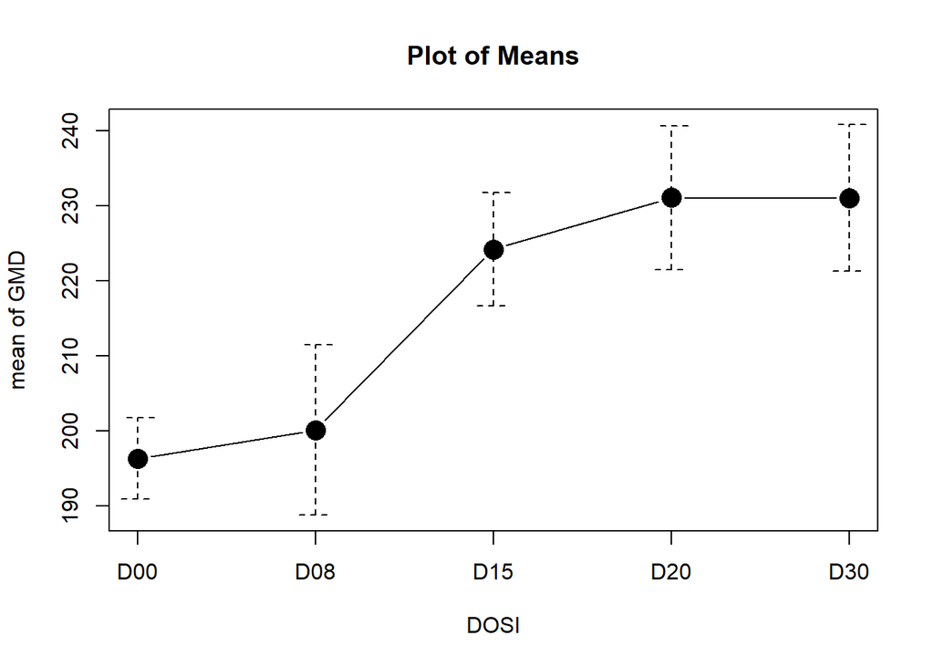

```r
with(dd,plotMeans(GMD,DOSI,error.bars = "sd"))
```

*Models i resums*

```r
summary(m<-lm(GMD~DOSI,dd))
```

```
##
## Call:
## lm(formula = GMD ~ DOSI, data = dd)
##
## Residuals:
##     Min      1Q  Median      3Q     Max
## -15.152  -6.734  -0.482   8.132  11.518
##
## Coefficients:
##             Estimate Std. Error t value Pr(>|t|)
## (Intercept)  196.350      4.006  49.014  < 2e-16 ***
## DOSID08        3.802      5.665   0.671     0.51
## DOSID15       27.848      5.665   4.916 8.35e-05 ***
## DOSID20       34.714      5.665   6.127 5.48e-06 ***
## DOSID30       34.684      5.665   6.122 5.55e-06 ***
## ---
## Signif. codes:  0 '***' 0.001 '**' 0.01 '*' 0.05 '.' 0.1 ' ' 1
##
## Residual standard error: 8.958 on 20 degrees of freedom
## Multiple R-squared:  0.7827, Adjusted R-squared:  0.7392
## F-statistic: 18.01 on 4 and 20 DF,  p-value: 2.075e-06
```

```r
m0<-lm(GMD~1,dd)
summary(mg<-glm(GMD~DOSI,family=gaussian,dd))
```

```
##
## Call:
## glm(formula = GMD ~ DOSI, family = gaussian, data = dd)
##
## Deviance Residuals:
##     Min       1Q   Median       3Q      Max
## -15.152   -6.734   -0.482    8.132   11.518
##
## Coefficients:
##             Estimate Std. Error t value Pr(>|t|)
## (Intercept)  196.350      4.006  49.014  < 2e-16 ***
## DOSID08        3.802      5.665   0.671     0.51
## DOSID15       27.848      5.665   4.916 8.35e-05 ***
## DOSID20       34.714      5.665   6.127 5.48e-06 ***
## DOSID30       34.684      5.665   6.122 5.55e-06 ***
## ---
## Signif. codes:  0 '***' 0.001 '**' 0.01 '*' 0.05 '.' 0.1 ' ' 1
##
## (Dispersion parameter for gaussian family taken to be 80.23991)
##
##     Null deviance: 7384.1  on 24  degrees of freedom
## Residual deviance: 1604.8  on 20  degrees of freedom
## AIC: 186.99
##
## Number of Fisher Scoring iterations: 2
```

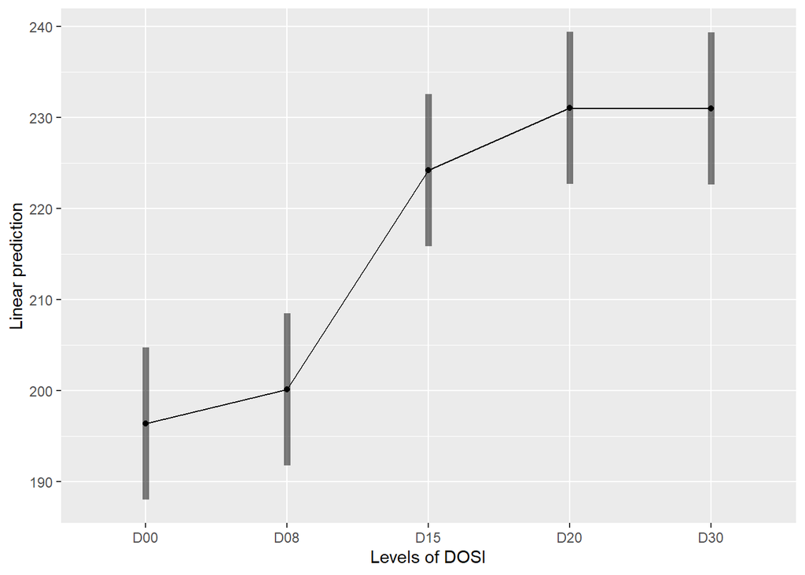

```r
mg0<-glm(GMD~1,family=gaussian,dd)

emmip(m,~DOSI,CIs=T)
```

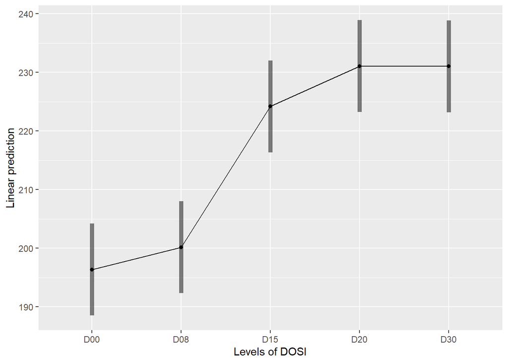

```r
emmip(mg,~DOSI,CIs=T)
```

*Tests Anova Omnibus*

```r
anova(m0,m)
```

```
## Analysis of Variance Table
##
## Model 1: GMD ~ 1
## Model 2: GMD ~ DOSI
##   Res.Df    RSS Df Sum of Sq      F    Pr(>F)
## 1     24 7384.1
## 2     20 1604.8  4    5779.3 18.006 2.075e-06 ***
## ---
## Signif. codes:  0 '***' 0.001 '**' 0.01 '*' 0.05 '.' 0.1 ' ' 1
```

```r
anova(mg0,mg,test="F")
```

```
## Analysis of Deviance Table
##
## Model 1: GMD ~ 1
## Model 2: GMD ~ DOSI
##   Resid. Df Resid. Dev Df Deviance      F    Pr(>F)
## 1        24     7384.1
## 2        20     1604.8  4   5779.3 18.006 2.075e-06 ***
## ---
## Signif. codes:  0 '***' 0.001 '**' 0.01 '*' 0.05 '.' 0.1 ' ' 1
```

*Tests Anova*

```r
Anova(m)
```

```
## Anova Table (Type II tests)
##
## Response: GMD
##           Sum Sq Df F value    Pr(>F)
## DOSI      5779.3  4  18.006 2.075e-06 ***
## Residuals 1604.8 20
## ---
## Signif. codes:  0 '***' 0.001 '**' 0.01 '*' 0.05 '.' 0.1 ' ' 1
```

```r
Anova(mg,test.statistic = "F")
```

```
## Analysis of Deviance Table (Type II tests)
##
## Response: GMD
## Error estimate based on Pearson residuals
##
##           Sum Sq Df F value    Pr(>F)
## DOSI      5779.3  4  18.006 2.075e-06 ***
## Residuals 1604.8 20
## ---
## Signif. codes:  0 '***' 0.001 '**' 0.01 '*' 0.05 '.' 0.1 ' ' 1
```

```r
#Suma de quadrats residual i deviància són iguals
mg$deviance
```

```
## [1] 1604.798
```

```r
#Suma de quadrats dosi i diferència null.deviance-deviance són iguals
mg$null.deviance-mg$deviance
```

```
## [1] 5779.341
```

```r
#Mitjana de quadrats de l'error i parametre de dispersió són iguals
c("MDE"=summary(m)$sigma^2,"Disp."=summary(mg)$dispersion,"càlcul"=mg$deviance/mg$df.residual)
```

```
##      MDE    Disp.   càlcul
## 80.23991 80.23991 80.23991
```

*Estimació esperances marginals i comparacions múltiples*

```r
#L'única diferència són els graus de llibertat, a mg df=inf equivalent a asimptòticament normal
(em<-emmeans(m,~DOSI))
```

```
##  DOSI emmean   SE df lower.CL upper.CL
##  D00     196 4.01 20      188      205
##  D08     200 4.01 20      192      209
##  D15     224 4.01 20      216      233
##  D20     231 4.01 20      223      239
##  D30     231 4.01 20      223      239
##
## Confidence level used: 0.95
```

```r
(emg<-emmeans(mg,~DOSI))
```

```
##  DOSI emmean   SE  df asymp.LCL asymp.UCL
##  D00     196 4.01 Inf       188       204
##  D08     200 4.01 Inf       192       208
##  D15     224 4.01 Inf       216       232
##  D20     231 4.01 Inf       223       239
##  D30     231 4.01 Inf       223       239
##
## Confidence level used: 0.95
```

```r
#Degut als graus de llibertat, lleugeres diferències en els p-valors
pairs(em)
```

```
##  contrast  estimate   SE df t.ratio p.value
##  D00 - D08    -3.80 5.67 20 -0.671  0.9604
##  D00 - D15   -27.85 5.67 20 -4.916  0.0007
##  D00 - D20   -34.71 5.67 20 -6.127  <.0001
##  D00 - D30   -34.68 5.67 20 -6.122  <.0001
##  D08 - D15   -24.05 5.67 20 -4.244  0.0032
##  D08 - D20   -30.91 5.67 20 -5.456  0.0002
##  D08 - D30   -30.88 5.67 20 -5.451  0.0002
##  D15 - D20    -6.87 5.67 20 -1.212  0.7447
##  D15 - D30    -6.84 5.67 20 -1.207  0.7477
##  D20 - D30     0.03 5.67 20  0.005  1.0000
##
## P value adjustment: tukey method for comparing a family of 5 estimates
```

```r
pairs(emg)
```

```
##  contrast  estimate   SE  df z.ratio p.value
##  D00 - D08    -3.80 5.67 Inf -0.671  0.9626
##  D00 - D15   -27.85 5.67 Inf -4.916  <.0001
##  D00 - D20   -34.71 5.67 Inf -6.127  <.0001
##  D00 - D30   -34.68 5.67 Inf -6.122  <.0001
##  D08 - D15   -24.05 5.67 Inf -4.244  0.0002
##  D08 - D20   -30.91 5.67 Inf -5.456  <.0001
##  D08 - D30   -30.88 5.67 Inf -5.451  <.0001
##  D15 - D20    -6.87 5.67 Inf -1.212  0.7445
##  D15 - D30    -6.84 5.67 Inf -1.207  0.7476
##  D20 - D30     0.03 5.67 Inf  0.005  1.0000
##
## P value adjustment: tukey method for comparing a family of 5 estimates
```

```r
CLD(em)
```

```
##  DOSI emmean   SE df lower.CL upper.CL .group
##  D00     196 4.01 20      188      205  1
##  D08     200 4.01 20      192      209  1
##  D15     224 4.01 20      216      233   2
##  D30     231 4.01 20      223      239   2
##  D20     231 4.01 20      223      239   2
##
## Confidence level used: 0.95
## P value adjustment: tukey method for comparing a family of 5 estimates
## significance level used: alpha = 0.05
```

```r
CLD(emg)
```

```
##  DOSI emmean   SE  df asymp.LCL asymp.UCL .group
##  D00     196 4.01 Inf       188       204  1
##  D08     200 4.01 Inf       192       208  1
##  D15     224 4.01 Inf       216       232   2
##  D30     231 4.01 Inf       223       239   2
##  D20     231 4.01 Inf       223       239   2
##
## Confidence level used: 0.95
## P value adjustment: tukey method for comparing a family of 5 estimates
## significance level used: alpha = 0.05
```

####b) Ara en lloc de GMD, amb la variable IC, que és la relació entre “la quantitat de pinso consumit” i “l’augment de pes”:

####Les variables que són relació entre dues variables, com l’índex de canvi entre dues divises, o l’índex de conversió del pinso, es poden definir també amb la relació inversa. Sovint es considera que aquest tipus de variable segueix una distribució Inversa Gaussiana.

####Ajusteu un model inversa gaussiana amb el link canònic 1/mu^2:

*Descriptiva i models*

```r
print(tabular(DOSI~IC*((Dades=1)+(Mitjana=mean)+(Desv.Tipus=sd)),dd),justification="r")
```

```
##
##          IC
##  DOSI Dades Mitjana Desv.Tipus
##   D00     5   2.118    0.05357
##   D08     5   2.102    0.08228
##   D15     5   1.956    0.06656
##   D20     5   2.018    0.08497
##   D30     5   2.056    0.08050
```

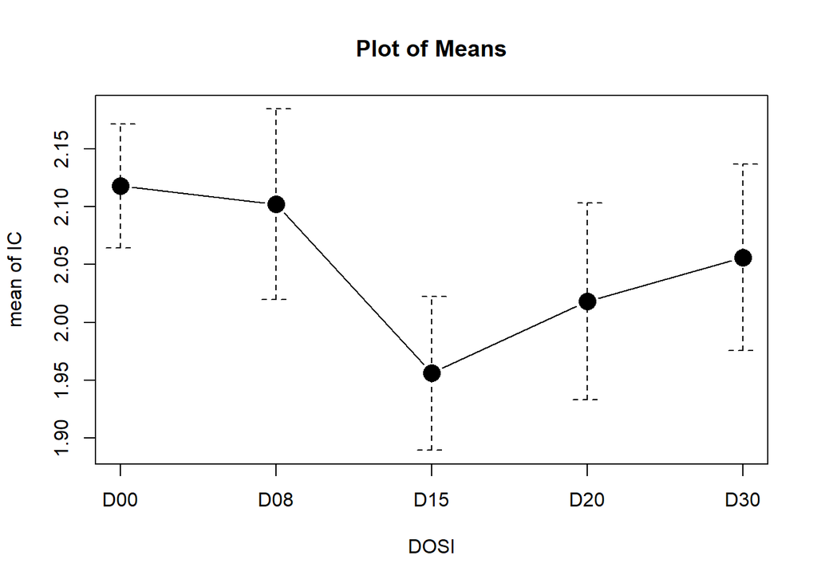

```r
with(dd,plotMeans(IC,DOSI,error.bars = "sd"))
```

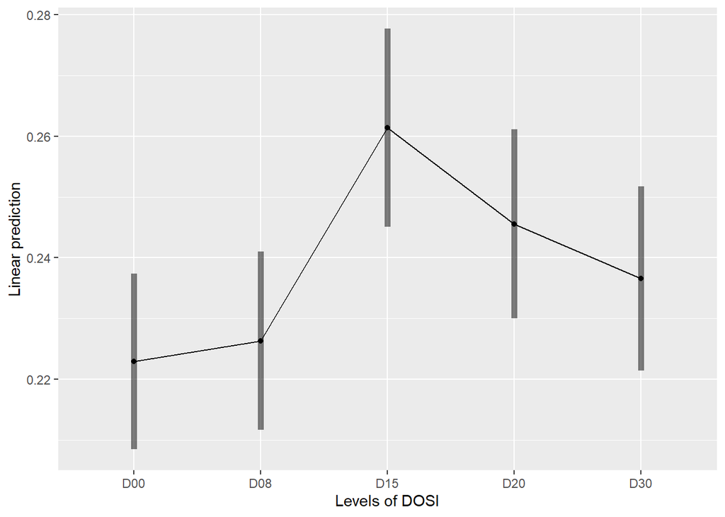

```r
mig<-glm(IC~DOSI,family=inverse.gaussian,dd)
emmip(mig,~DOSI,CIs=T)
```

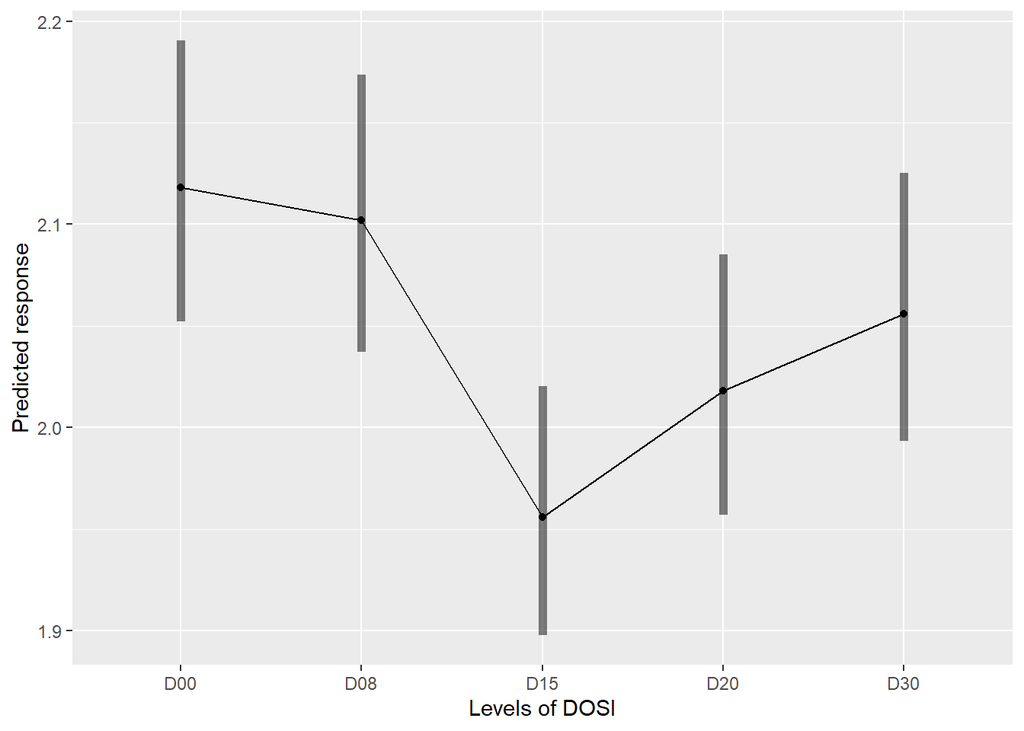

```r
emmip(mig,~DOSI,CIs=T,ty="response")
```

**• Per cada nivell de dosi, estimeu els valors esperats del IC i el seu interval de confiança.**

```r
(emig<-emmeans(mig,~DOSI,ty="response"))
```

```
##  DOSI response     SE  df asymp.LCL asymp.UCL
##  D00      2.12 0.0351 Inf      2.05      2.19
##  D08      2.10 0.0347 Inf      2.04      2.17
##  D15      1.96 0.0312 Inf      1.90      2.02
##  D20      2.02 0.0327 Inf      1.96      2.09
##  D30      2.06 0.0336 Inf      1.99      2.13
##
## Confidence level used: 0.95
## Intervals are back-transformed from the 1/mu^2 scale
```

• Feu les comparacions de totes les dosis entre elles. Dieu quines parelles de nivell de dosi, donen un IC esperat diferent.

```r
pairs(emig)
```

```
## Note: Use 'contrast(regrid(object), ...)' to obtain contrasts of back-transformed estimates
```

```
##  contrast  estimate     SE  df z.ratio p.value
##  D00 - D08 -0.00341 0.0105 Inf -0.324  0.9976
##  D00 - D15 -0.03845 0.0111 Inf -3.452  0.0051
##  D00 - D20 -0.02264 0.0109 Inf -2.085  0.2264
##  D00 - D30 -0.01365 0.0107 Inf -1.276  0.7063
##  D08 - D15 -0.03505 0.0112 Inf -3.130  0.0151
##  D08 - D20 -0.01923 0.0109 Inf -1.762  0.3960
##  D08 - D30 -0.01024 0.0108 Inf -0.952  0.8764
##  D15 - D20  0.01581 0.0115 Inf  1.373  0.6450
##  D15 - D30  0.02481 0.0114 Inf  2.182  0.1863
##  D20 - D30  0.00899 0.0111 Inf  0.811  0.9274
##
## Note: contrasts are still on the 1/mu^2 scale
## P value adjustment: tukey method for comparing a family of 5 estimates
```

• Expresseu el resultat anterior de forma compacta.

```r
CLD(emig)
```

```
## Note: Use 'contrast(regrid(object), ...)' to obtain contrasts of back-transformed estimates
```

```
##  DOSI response     SE  df asymp.LCL asymp.UCL .group
##  D15      1.96 0.0312 Inf      1.90      2.02  1
##  D20      2.02 0.0327 Inf      1.96      2.09  12
##  D30      2.06 0.0336 Inf      1.99      2.13  12
##  D08      2.10 0.0347 Inf      2.04      2.17   2
##  D00      2.12 0.0351 Inf      2.05      2.19   2
##
## Confidence level used: 0.95
## Intervals are back-transformed from the 1/mu^2 scale
## Note: contrasts are still on the 1/mu^2 scale
## P value adjustment: tukey method for comparing a family of 5 estimates
## significance level used: alpha = 0.05
```

**• Com afecta als resultats si canvieu el link? Per exemple link=identity** *Quan només hi ha un factor, o només factors amb totes les interaccions, el link no afecta a les deviàncies ni a les estimacions de les esperances marginals*

```r
summary(mig)
```

```
##
## Call:
## glm(formula = IC ~ DOSI, family = inverse.gaussian, data = dd)
##
## Deviance Residuals:
##       Min         1Q     Median         3Q        Max
## -0.042421  -0.020770  -0.000657   0.015574   0.034715
##
## Coefficients:
##             Estimate Std. Error t value Pr(>|t|)
## (Intercept) 0.222920   0.007395  30.146  < 2e-16 ***
## DOSID08     0.003407   0.010518   0.324  0.74939
## DOSID15     0.038454   0.011140   3.452  0.00252 **
## DOSID20     0.022641   0.010858   2.085  0.05009 .
## DOSID30     0.013647   0.010699   1.276  0.21671
## ---
## Signif. codes:  0 '***' 0.001 '**' 0.01 '*' 0.05 '.' 0.1 ' ' 1
##
## (Dispersion parameter for inverse.gaussian family taken to be 0.0006494364)
##
##     Null deviance: 0.023177  on 24  degrees of freedom
## Residual deviance: 0.013049  on 20  degrees of freedom
## AIC: -52.233
##
## Number of Fisher Scoring iterations: 3
```

```r
summary(migi<-glm(IC~DOSI,family=inverse.gaussian(link=identity),dd))
```

```
##
## Call:
## glm(formula = IC ~ DOSI, family = inverse.gaussian(link = identity),
##     data = dd)
##
## Deviance Residuals:
##       Min         1Q     Median         3Q        Max
## -0.042421  -0.020770  -0.000657   0.015574   0.034715
##
## Coefficients:
##             Estimate Std. Error t value Pr(>|t|)
## (Intercept)  2.11800    0.03513  60.292  < 2e-16 ***
## DOSID08     -0.01600    0.04940  -0.324  0.74939
## DOSID15     -0.16200    0.04697  -3.449  0.00254 **
## DOSID20     -0.10000    0.04797  -2.084  0.05015 .
## DOSID30     -0.06200    0.04861  -1.275  0.21676
## ---
## Signif. codes:  0 '***' 0.001 '**' 0.01 '*' 0.05 '.' 0.1 ' ' 1
##
## (Dispersion parameter for inverse.gaussian family taken to be 0.0006494272)
##
##     Null deviance: 0.023177  on 24  degrees of freedom
## Residual deviance: 0.013049  on 20  degrees of freedom
## AIC: -52.233
##
## Number of Fisher Scoring iterations: 3
```

```r
emig
```

```
##  DOSI response     SE  df asymp.LCL asymp.UCL
##  D00      2.12 0.0351 Inf      2.05      2.19
##  D08      2.10 0.0347 Inf      2.04      2.17
##  D15      1.96 0.0312 Inf      1.90      2.02
##  D20      2.02 0.0327 Inf      1.96      2.09
##  D30      2.06 0.0336 Inf      1.99      2.13
##
## Confidence level used: 0.95
## Intervals are back-transformed from the 1/mu^2 scale
```

```r
(emigi<-emmeans(migi,~DOSI,ty="response"))
```

```
##  DOSI emmean     SE  df asymp.LCL asymp.UCL
##  D00    2.12 0.0351 Inf      2.05      2.19
##  D08    2.10 0.0347 Inf      2.03      2.17
##  D15    1.96 0.0312 Inf      1.89      2.02
##  D20    2.02 0.0327 Inf      1.95      2.08
##  D30    2.06 0.0336 Inf      1.99      2.12
##
## Confidence level used: 0.95
```

```r
pairs(emig)
```

```
## Note: Use 'contrast(regrid(object), ...)' to obtain contrasts of back-transformed estimates
```

```
##  contrast  estimate     SE  df z.ratio p.value
##  D00 - D08 -0.00341 0.0105 Inf -0.324  0.9976
##  D00 - D15 -0.03845 0.0111 Inf -3.452  0.0051
##  D00 - D20 -0.02264 0.0109 Inf -2.085  0.2264
##  D00 - D30 -0.01365 0.0107 Inf -1.276  0.7063
##  D08 - D15 -0.03505 0.0112 Inf -3.130  0.0151
##  D08 - D20 -0.01923 0.0109 Inf -1.762  0.3960
##  D08 - D30 -0.01024 0.0108 Inf -0.952  0.8764
##  D15 - D20  0.01581 0.0115 Inf  1.373  0.6450
##  D15 - D30  0.02481 0.0114 Inf  2.182  0.1863
##  D20 - D30  0.00899 0.0111 Inf  0.811  0.9274
##
## Note: contrasts are still on the 1/mu^2 scale
## P value adjustment: tukey method for comparing a family of 5 estimates
```

```r
pairs(emigi)
```

```
##  contrast  estimate     SE  df z.ratio p.value
##  D00 - D08    0.016 0.0494 Inf  0.324  0.9976
##  D00 - D15    0.162 0.0470 Inf  3.449  0.0051
##  D00 - D20    0.100 0.0480 Inf  2.084  0.2267
##  D00 - D30    0.062 0.0486 Inf  1.275  0.7064
##  D08 - D15    0.146 0.0467 Inf  3.128  0.0152
##  D08 - D20    0.084 0.0477 Inf  1.762  0.3962
##  D08 - D30    0.046 0.0483 Inf  0.952  0.8764
##  D15 - D20   -0.062 0.0452 Inf -1.373  0.6451
##  D15 - D30   -0.100 0.0458 Inf -2.182  0.1865
##  D20 - D30   -0.038 0.0469 Inf -0.811  0.9274
##
## P value adjustment: tukey method for comparing a family of 5 estimates
```

**• Es compleixen les condicions dels models lineals generalitzats?**

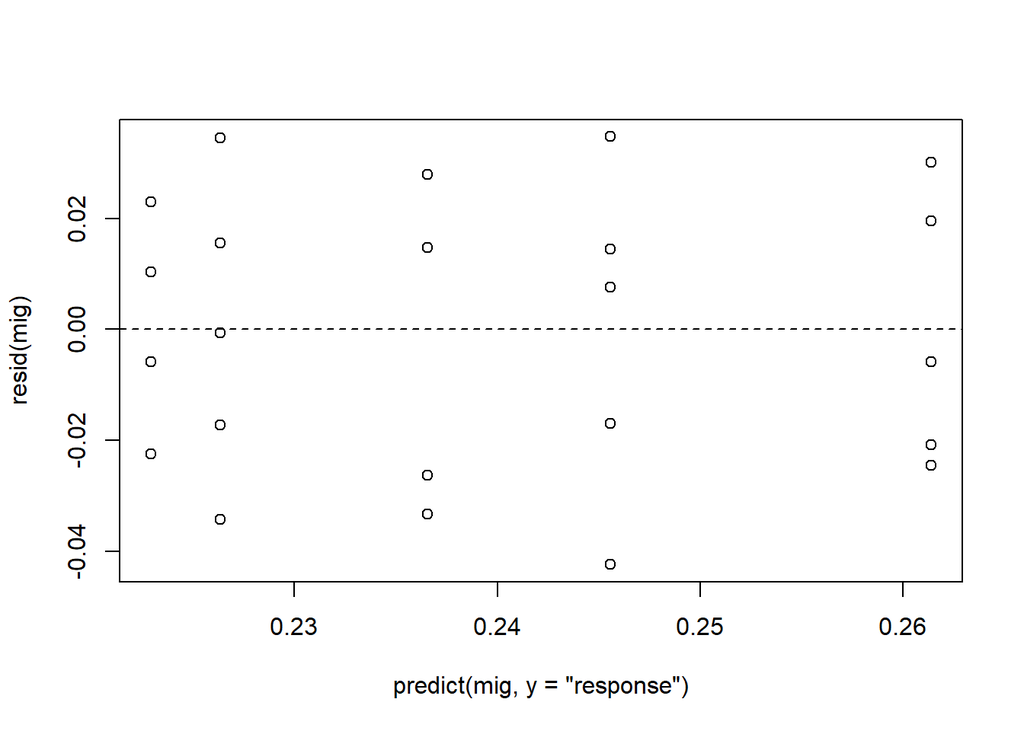

```r
plot(predict(mig,y="response"),resid(mig))
abline(h=0,lt=2)
```

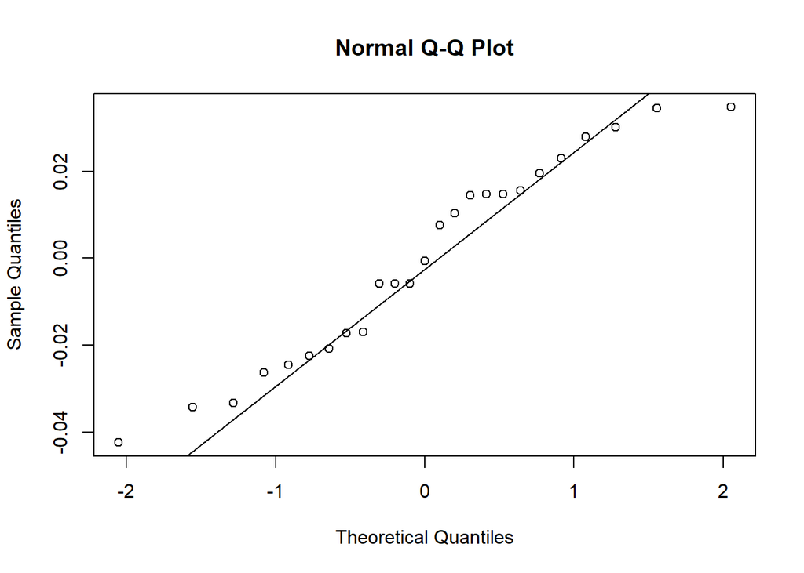

```r
qqnorm(resid(mig))
qqline(resid(mig))
```

```r
leveneTest(resid(mig)~DOSI,dd)
```

```
## Levene's Test for Homogeneity of Variance (center = median)
##       Df F value Pr(>F)
## group  4  0.2417 0.9113
##       20
```